# Practical Machine Learning - Final Project

Victor Ceron

June 2, 2018

# Title: “Practical Machine Learning - Project”

## Part 1: Analysis Description

### Explanation of dataset:

Using devices such as Jawbone Up, Nike FuelBand, and Fitbit it is now possible to collect a large amount of data about personal activity relatively inexpensively. We propose a dataset with 5 classes (sitting-down, standing-up, standing, walking, and sitting) collected on 8 hours of activities of 4 healthy subjects.

### Purpose:

Below we build several models and assess their out-of-sample effectiveness. We build individual Random Forest, Naive Bayes and Gradient Boosting Algorithm; also, we combine these 3 models using Generalize Additive Model.

### 0. Load packages

```r
library(caret)
library(lubridate)
library(doParallel)
library(rattle)
```

### 1. Load data: Data is loaded and every blank, NA and #Div/0! are classified as NAs.

```r
setwd("Z:/Victor/Data Science/Practical Machine Learning")
pml_training<-read.csv("pml-training.csv", na.strings = c("#DIV/0!", "", "NA"))
pml_testing<-read.csv("pml-testing.csv", na.strings = c("#DIV/0!", "", "NA"))
```

After looking at the data, a decision was made that timestamp data, user name, and window information are not useful to build a prediction model. Also, by looking at near-zero variance data, the decision was reinforced to discard new_window information.

Both criteria call for discarding columns 1 to 7. This is a welcome development as we can make our model more efficient by dropping irrelevant variables.

```r
pml<-complete.cases(pml_testing) #complete.cases returns a logical vector indicating which cases are complete, i.e., have no missing values
pml_testing_noNAscols<-pml_testing[,colSums(is.na(pml_testing))<nrow(pml_testing)]
pml_training_noNAscols<-pml_training[,colSums(is.na(pml_training))<nrow(pml_training)]
cols_to_keep<-intersect(colnames(pml_testing_noNAscols),colnames(pml_training_noNAscols))
pml_testing_noNAscols_common<-pml_testing_noNAscols[,cols_to_keep, drop=FALSE]
pml_training_noNAscols_common<-pml_training_noNAscols[,cols_to_keep, drop=FALSE]
nearZeroVar(pml_training_noNAscols_common,saveMetrics = TRUE)
```

```
##                      freqRatio percentUnique zeroVar   nzv
## X                     1.000000  100.00000000   FALSE FALSE
## user_name             1.100679    0.03057792   FALSE FALSE
## raw_timestamp_part_1  1.000000    4.26562022   FALSE FALSE
## raw_timestamp_part_2  1.000000   85.53154622   FALSE FALSE
## cvtd_timestamp        1.000668    0.10192641   FALSE FALSE
## new_window           47.330049    0.01019264   FALSE  TRUE
## num_window            1.000000    4.37264295   FALSE FALSE
## roll_belt             1.101904    6.77810621   FALSE FALSE
## pitch_belt            1.036082    9.37722964   FALSE FALSE
## yaw_belt              1.058480    9.97349913   FALSE FALSE
## total_accel_belt      1.063160    0.14779329   FALSE FALSE
## gyros_belt_x          1.058651    0.71348486   FALSE FALSE
## gyros_belt_y          1.144000    0.35164611   FALSE FALSE
## gyros_belt_z          1.066214    0.86127816   FALSE FALSE
## accel_belt_x          1.055412    0.83579655   FALSE FALSE
## accel_belt_y          1.113725    0.72877383   FALSE FALSE
## accel_belt_z          1.078767    1.52379982   FALSE FALSE
## magnet_belt_x         1.090141    1.66649679   FALSE FALSE
## magnet_belt_y         1.099688    1.51870350   FALSE FALSE
## magnet_belt_z         1.006369    2.32901845   FALSE FALSE
## roll_arm             52.338462   13.52563449   FALSE FALSE
## pitch_arm            87.256410   15.73234125   FALSE FALSE
## yaw_arm              33.029126   14.65701763   FALSE FALSE
## total_accel_arm       1.024526    0.33635715   FALSE FALSE
## gyros_arm_x           1.015504    3.27693405   FALSE FALSE
## gyros_arm_y           1.454369    1.91621649   FALSE FALSE
## gyros_arm_z           1.110687    1.26388747   FALSE FALSE
## accel_arm_x           1.017341    3.95984099   FALSE FALSE
## accel_arm_y           1.140187    2.73672409   FALSE FALSE
## accel_arm_z           1.128000    4.03628580   FALSE FALSE
## magnet_arm_x          1.000000    6.82397309   FALSE FALSE
## magnet_arm_y          1.056818    4.44399144   FALSE FALSE
## magnet_arm_z          1.036364    6.44684538   FALSE FALSE
## roll_dumbbell         1.022388   84.20650290   FALSE FALSE
## pitch_dumbbell        2.277372   81.74498012   FALSE FALSE
## yaw_dumbbell          1.132231   83.48282540   FALSE FALSE
## total_accel_dumbbell  1.072634    0.21914178   FALSE FALSE
## gyros_dumbbell_x      1.003268    1.22821323   FALSE FALSE
## gyros_dumbbell_y      1.264957    1.41677709   FALSE FALSE
## gyros_dumbbell_z      1.060100    1.04984201   FALSE FALSE
## accel_dumbbell_x      1.018018    2.16593619   FALSE FALSE
## accel_dumbbell_y      1.053061    2.37488533   FALSE FALSE
## accel_dumbbell_z      1.133333    2.08949139   FALSE FALSE
## magnet_dumbbell_x     1.098266    5.74864948   FALSE FALSE
## magnet_dumbbell_y     1.197740    4.30129447   FALSE FALSE
## magnet_dumbbell_z     1.020833    3.44511263   FALSE FALSE
## roll_forearm         11.589286   11.08959331   FALSE FALSE
## pitch_forearm        65.983051   14.85577413   FALSE FALSE
## yaw_forearm          15.322835   10.14677403   FALSE FALSE
## total_accel_forearm   1.128928    0.35674243   FALSE FALSE
## gyros_forearm_x       1.059273    1.51870350   FALSE FALSE
## gyros_forearm_y       1.036554    3.77637346   FALSE FALSE
## gyros_forearm_z       1.122917    1.56457038   FALSE FALSE
## accel_forearm_x       1.126437    4.04647844   FALSE FALSE
## accel_forearm_y       1.059406    5.11160942   FALSE FALSE
## accel_forearm_z       1.006250    2.95586586   FALSE FALSE
## magnet_forearm_x      1.012346    7.76679238   FALSE FALSE
## magnet_forearm_y      1.246914    9.54031189   FALSE FALSE
## magnet_forearm_z      1.000000    8.57710733   FALSE FALSE
```

```r
nearZeroVar(pml_testing_noNAscols_common,saveMetrics = TRUE)
```

```
##                      freqRatio percentUnique zeroVar   nzv
## X                     1.000000           100   FALSE FALSE
## user_name             2.000000            30   FALSE FALSE
## raw_timestamp_part_1  1.000000           100   FALSE FALSE
## raw_timestamp_part_2  1.000000           100   FALSE FALSE
## cvtd_timestamp        1.333333            55   FALSE FALSE
## new_window            0.000000             5    TRUE  TRUE
## num_window            1.000000           100   FALSE FALSE
## roll_belt             1.000000            90   FALSE FALSE
## pitch_belt            1.000000           100   FALSE FALSE
## yaw_belt              1.000000            90   FALSE FALSE
## total_accel_belt      1.200000            45   FALSE FALSE
## gyros_belt_x          1.500000            70   FALSE FALSE
## gyros_belt_y          2.250000            30   FALSE FALSE
## gyros_belt_z          2.500000            65   FALSE FALSE
## accel_belt_x          1.000000            85   FALSE FALSE
## accel_belt_y          1.500000            75   FALSE FALSE
## accel_belt_z          1.000000            85   FALSE FALSE
## magnet_belt_x         1.000000           100   FALSE FALSE
## magnet_belt_y         1.500000            80   FALSE FALSE
## magnet_belt_z         1.500000            80   FALSE FALSE
## roll_arm              8.000000            65   FALSE FALSE
## pitch_arm             8.000000            65   FALSE FALSE
## yaw_arm               8.000000            65   FALSE FALSE
## total_accel_arm       1.000000            85   FALSE FALSE
## gyros_arm_x           2.000000            95   FALSE FALSE
## gyros_arm_y           2.000000            95   FALSE FALSE
## gyros_arm_z           1.000000            90   FALSE FALSE
## accel_arm_x           2.000000            95   FALSE FALSE
## accel_arm_y           1.000000           100   FALSE FALSE
## accel_arm_z           1.000000           100   FALSE FALSE
## magnet_arm_x          1.000000           100   FALSE FALSE
## magnet_arm_y          2.000000            95   FALSE FALSE
## magnet_arm_z          1.000000           100   FALSE FALSE
## roll_dumbbell         1.000000           100   FALSE FALSE
## pitch_dumbbell        1.000000           100   FALSE FALSE
## yaw_dumbbell          1.000000           100   FALSE FALSE
## total_accel_dumbbell  2.000000            70   FALSE FALSE
## gyros_dumbbell_x      1.000000            90   FALSE FALSE
## gyros_dumbbell_y      1.000000            80   FALSE FALSE
## gyros_dumbbell_z      4.000000            85   FALSE FALSE
## accel_dumbbell_x      1.000000           100   FALSE FALSE
## accel_dumbbell_y      3.000000            90   FALSE FALSE
## accel_dumbbell_z      2.000000            95   FALSE FALSE
## magnet_dumbbell_x     1.000000           100   FALSE FALSE
## magnet_dumbbell_y     1.000000           100   FALSE FALSE
## magnet_dumbbell_z     2.000000            95   FALSE FALSE
## roll_forearm          2.000000            95   FALSE FALSE
## pitch_forearm         1.000000           100   FALSE FALSE
## yaw_forearm           1.000000           100   FALSE FALSE
## total_accel_forearm   1.500000            65   FALSE FALSE
## gyros_forearm_x       1.000000            90   FALSE FALSE
## gyros_forearm_y       1.000000           100   FALSE FALSE
## gyros_forearm_z       1.000000           100   FALSE FALSE
## accel_forearm_x       1.000000           100   FALSE FALSE
## accel_forearm_y       1.000000           100   FALSE FALSE
## accel_forearm_z       1.000000           100   FALSE FALSE
## magnet_forearm_x      1.000000           100   FALSE FALSE
## magnet_forearm_y      1.000000           100   FALSE FALSE
## magnet_forearm_z      1.000000           100   FALSE FALSE
```

```r
pml_testing_noNAscols_common_noNZV<-pml_testing_noNAscols_common[,-c(1:7)]
pml_training_noNAscols_common_noNZV<-pml_training_noNAscols_common[,-c(1:7)]
pml_training_noNAscols_common_noNZV$classe<-pml_training$classe
```

### 3. Data splitting: We split the training set in 3 parts: TRAIN, TEST and VAL (validation). Given that the data has a temporal component. It was decided to split the data 70%/15%/15% respectively

```r
index_train <- caret::createDataPartition(y=pml_training$classe, p=0.70, list=FALSE)

TRAIN_pml_training_noNAscols_common_noNZV<-pml_training_noNAscols_common_noNZV[index_train,]
preTEST_pml_training_noNAscols_common_noNZV<-pml_training_noNAscols_common_noNZV[-index_train,]
index_test_val <- caret::createDataPartition(y=preTEST_pml_training_noNAscols_common_noNZV$classe, p=0.50, list=FALSE)
VAL_pml_training_noNAscols_common_noNZV<-preTEST_pml_training_noNAscols_common_noNZV[-index_test_val,]
TEST_pml_training_noNAscols_common_noNZV<-preTEST_pml_training_noNAscols_common_noNZV[index_test_val,]
```

### 4. Allow parallel processing and define train control paameters to allow for repeated cross-validation.

```r
set.seed(1409)
cl<-makeCluster(3)
registerDoParallel( cl )
trControl <- caret::trainControl( method = "repeatedcv", number = 10, repeats = 5, verboseIter = FALSE, allowParallel = TRUE )
```

### 5.1 Build random forest model. And run the model using the TEST set. Accuracy ~ 100%….

```r
ModRF <- train(classe~., data = TRAIN_pml_training_noNAscols_common_noNZV, trControl = trControl, method = "rf" )
```

```r
PredRF_Test<-predict(ModRF,newdata=TEST_pml_training_noNAscols_common_noNZV)
confRF<-confusionMatrix(TEST_pml_training_noNAscols_common_noNZV$classe,PredRF_Test)
confRF
```

```
## Confusion Matrix and Statistics
##
##           Reference
## Prediction    A    B    C    D    E
##          A 2788    1    0    0    0
##          B    0  154    0    0    0
##          C    0    0    0    0    0
##          D    0    0    0    0    0
##          E    0    0    0    0    0
##
## Overall Statistics
##
##                Accuracy : 0.9997
##                  95% CI : (0.9981, 1)
##     No Information Rate : 0.9473
##     P-Value [Acc > NIR] : < 2.2e-16
##
##                   Kappa : 0.9966
##  Mcnemar's Test P-Value : NA
##
## Statistics by Class:
##
##                      Class: A Class: B Class: C Class: D Class: E
## Sensitivity            1.0000  0.99355       NA       NA       NA
## Specificity            0.9935  1.00000        1        1        1
## Pos Pred Value         0.9996  1.00000       NA       NA       NA
## Neg Pred Value         1.0000  0.99964       NA       NA       NA
## Prevalence             0.9473  0.05267        0        0        0
## Detection Rate         0.9473  0.05233        0        0        0
## Detection Prevalence   0.9477  0.05233        0        0        0
## Balanced Accuracy      0.9968  0.99677       NA       NA       NA
```

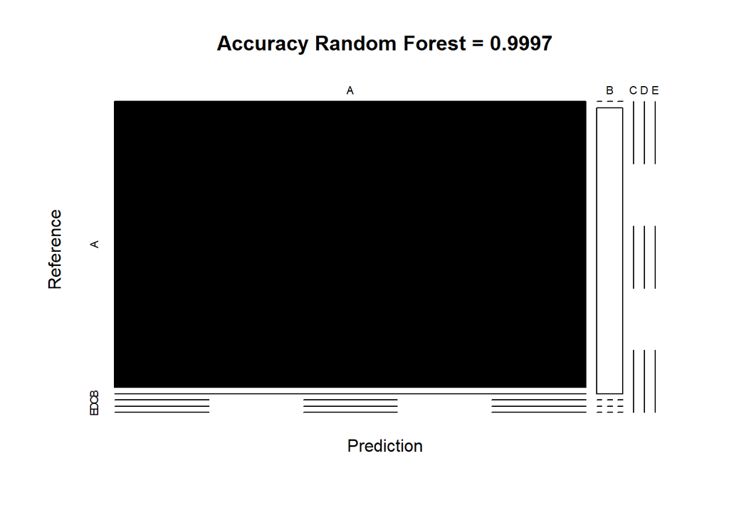

```r
plot(confRF$table, col = confRF$byClass, main = paste("Accuracy Random Forest =", round(confRF$overall['Accuracy'], 4)))
```

### 5.2 Build Naive Bayes model. And run the model using the TEST set. Accuracy ~ 89%

```r
ModNB <- train(classe~., data = TRAIN_pml_training_noNAscols_common_noNZV, trControl = trControl, method = "nb" )
```

```r
PredNB_Test<-predict(ModNB,newdata=TEST_pml_training_noNAscols_common_noNZV)
confusionMatrix(TEST_pml_training_noNAscols_common_noNZV$classe,PredNB_Test)
```

```
## Confusion Matrix and Statistics
##
##           Reference
## Prediction    A    B    C    D    E
##          A 2494   56   79  148   12
##          B   32  111    3    8    0
##          C    0    0    0    0    0
##          D    0    0    0    0    0
##          E    0    0    0    0    0
##
## Overall Statistics
##
##                Accuracy : 0.8852
##                  95% CI : (0.8731, 0.8965)
##     No Information Rate : 0.8583
##     P-Value [Acc > NIR] : 1.015e-05
##
##                   Kappa : 0.3746
##  Mcnemar's Test P-Value : NA
##
## Statistics by Class:
##
##                      Class: A Class: B Class: C Class: D Class: E
## Sensitivity            0.9873  0.66467  0.00000  0.00000 0.000000
## Specificity            0.2926  0.98451  1.00000  1.00000 1.000000
## Pos Pred Value         0.8942  0.72078      NaN      NaN      NaN
## Neg Pred Value         0.7922  0.97992  0.97214  0.94699 0.995923
## Prevalence             0.8583  0.05674  0.02786  0.05301 0.004077
## Detection Rate         0.8474  0.03772  0.00000  0.00000 0.000000
## Detection Prevalence   0.9477  0.05233  0.00000  0.00000 0.000000
## Balanced Accuracy      0.6399  0.82459  0.50000  0.50000 0.500000
```

### 5.3 Build Gradient Boosting Algorithm model. And run the model using the TEST set. Accuracy ~ 99%

```r
ModGBM <- train(classe~., data = TRAIN_pml_training_noNAscols_common_noNZV, trControl = trControl, method = "gbm",verbose=FALSE )
```

```r
PredGBM_Test<-predict(ModGBM,newdata=TEST_pml_training_noNAscols_common_noNZV)
confusionMatrix(TEST_pml_training_noNAscols_common_noNZV$classe,PredGBM_Test)
```

```
## Confusion Matrix and Statistics
##
##           Reference
## Prediction    A    B    C    D    E
##          A 2757   21    8    1    2
##          B    6  148    0    0    0
##          C    0    0    0    0    0
##          D    0    0    0    0    0
##          E    0    0    0    0    0
##
## Overall Statistics
##
##                Accuracy : 0.9871
##                  95% CI : (0.9823, 0.9908)
##     No Information Rate : 0.9388
##     P-Value [Acc > NIR] : < 2.2e-16
##
##                   Kappa : 0.8796
##  Mcnemar's Test P-Value : NA
##
## Statistics by Class:
##
##                      Class: A Class: B Class: C  Class: D  Class: E
## Sensitivity            0.9978  0.87574 0.000000 0.0000000 0.0000000
## Specificity            0.8222  0.99784 1.000000 1.0000000 1.0000000
## Pos Pred Value         0.9885  0.96104      NaN       NaN       NaN
## Neg Pred Value         0.9610  0.99247 0.997282 0.9996602 0.9993204
## Prevalence             0.9388  0.05742 0.002718 0.0003398 0.0006796
## Detection Rate         0.9368  0.05029 0.000000 0.0000000 0.0000000
## Detection Prevalence   0.9477  0.05233 0.000000 0.0000000 0.0000000
## Balanced Accuracy      0.9100  0.93679 0.500000 0.5000000 0.5000000
```

### 5.4 Build combineed Generalize Additive Model by combining the previous 3 build models. As accuracy was already very high with the random forest model, this was done for exploratory purposes only

```r
GAMcomb<-data.frame(PredRF=PredRF_Test,PredNB=PredNB_Test,PredGBM=PredGBM_Test, classe=TEST_pml_training_noNAscols_common_noNZV$classe)
ModGAMcomb <- train(classe~., data = GAMcomb, trControl = trControl, method = "gam" )
```

### 5.5 Run every model in VAL set. [RF - 99.7%; NB- 74%; GBM - 97%; combined GAM - 21%]

```r
PredRF_VAL<-predict(ModRF,newdata=VAL_pml_training_noNAscols_common_noNZV)
confusionMatrix(VAL_pml_training_noNAscols_common_noNZV$classe,PredRF_VAL)
```

```
## Confusion Matrix and Statistics
##
##           Reference
## Prediction   A   B   C   D   E
##          A 837   0   0   0   0
##          B   3 566   0   0   0
##          C   0   4 509   0   0
##          D   0   0   2 480   0
##          E   0   0   0   0 541
##
## Overall Statistics
##
##                Accuracy : 0.9969
##                  95% CI : (0.9942, 0.9986)
##     No Information Rate : 0.2855
##     P-Value [Acc > NIR] : < 2.2e-16
##
##                   Kappa : 0.9961
##  Mcnemar's Test P-Value : NA
##
## Statistics by Class:
##
##                      Class: A Class: B Class: C Class: D Class: E
## Sensitivity            0.9964   0.9930   0.9961   1.0000   1.0000
## Specificity            1.0000   0.9987   0.9984   0.9992   1.0000
## Pos Pred Value         1.0000   0.9947   0.9922   0.9959   1.0000
## Neg Pred Value         0.9986   0.9983   0.9992   1.0000   1.0000
## Prevalence             0.2855   0.1937   0.1737   0.1632   0.1839
## Detection Rate         0.2845   0.1924   0.1730   0.1632   0.1839
## Detection Prevalence   0.2845   0.1934   0.1744   0.1638   0.1839
## Balanced Accuracy      0.9982   0.9959   0.9972   0.9996   1.0000
```

```r
PredNB_VAL<-predict(ModNB,newdata=VAL_pml_training_noNAscols_common_noNZV)
confusionMatrix(VAL_pml_training_noNAscols_common_noNZV$classe,PredNB_VAL)
```

```
## Confusion Matrix and Statistics
##
##           Reference
## Prediction   A   B   C   D   E
##          A 737  22  22  51   5
##          B 105 385  48  28   3
##          C 110  39 339  24   1
##          D 100   0  58 303  21
##          E  35  40  18  24 424
##
## Overall Statistics
##
##                Accuracy : 0.7437
##                  95% CI : (0.7275, 0.7594)
##     No Information Rate : 0.3695
##     P-Value [Acc > NIR] : < 2.2e-16
##
##                   Kappa : 0.6722
##  Mcnemar's Test P-Value : < 2.2e-16
##
## Statistics by Class:
##
##                      Class: A Class: B Class: C Class: D Class: E
## Sensitivity            0.6780   0.7922   0.6990   0.7047   0.9339
## Specificity            0.9461   0.9251   0.9292   0.9287   0.9530
## Pos Pred Value         0.8805   0.6766   0.6608   0.6286   0.7837
## Neg Pred Value         0.8337   0.9574   0.9399   0.9484   0.9875
## Prevalence             0.3695   0.1652   0.1649   0.1462   0.1543
## Detection Rate         0.2505   0.1309   0.1152   0.1030   0.1441
## Detection Prevalence   0.2845   0.1934   0.1744   0.1638   0.1839
## Balanced Accuracy      0.8121   0.8586   0.8141   0.8167   0.9434
```

```r
PredGBM_VAL<-predict(ModGBM,newdata=VAL_pml_training_noNAscols_common_noNZV)
confusionMatrix(VAL_pml_training_noNAscols_common_noNZV$classe,PredGBM_VAL)
```

```
## Confusion Matrix and Statistics
##
##           Reference
## Prediction   A   B   C   D   E
##          A 826   7   3   0   1
##          B  16 539  14   0   0
##          C   0  15 493   4   1
##          D   0   0  10 470   2
##          E   0   3   3   7 528
##
## Overall Statistics
##
##                Accuracy : 0.9708
##                  95% CI : (0.964, 0.9766)
##     No Information Rate : 0.2862
##     P-Value [Acc > NIR] : < 2.2e-16
##
##                   Kappa : 0.963
##  Mcnemar's Test P-Value : NA
##
## Statistics by Class:
##
##                      Class: A Class: B Class: C Class: D Class: E
## Sensitivity            0.9810   0.9557   0.9426   0.9771   0.9925
## Specificity            0.9948   0.9874   0.9917   0.9951   0.9946
## Pos Pred Value         0.9869   0.9473   0.9610   0.9751   0.9760
## Neg Pred Value         0.9924   0.9895   0.9876   0.9955   0.9983
## Prevalence             0.2862   0.1917   0.1778   0.1635   0.1808
## Detection Rate         0.2808   0.1832   0.1676   0.1598   0.1795
## Detection Prevalence   0.2845   0.1934   0.1744   0.1638   0.1839
## Balanced Accuracy      0.9879   0.9715   0.9672   0.9861   0.9935
```

```r
predGAMVAL<-data.frame(PredRF=PredRF_VAL,PredNB=PredNB_VAL,PredGBM=PredGBM_VAL)
combpredGAMVAL<-predict(ModGAMcomb,predGAMVAL)
confusionMatrix(VAL_pml_training_noNAscols_common_noNZV$classe,combpredGAMVAL)
```

```
## Confusion Matrix and Statistics
##
##           Reference
## Prediction   A   B   C   D   E
##          A  49 788   0   0   0
##          B   0 569   0   0   0
##          C  24 489   0   0   0
##          D 303 179   0   0   0
##          E  24 517   0   0   0
##
## Overall Statistics
##
##                Accuracy : 0.2101
##                  95% CI : (0.1955, 0.2252)
##     No Information Rate : 0.864
##     P-Value [Acc > NIR] : 1
##
##                   Kappa : 0.0054
##  Mcnemar's Test P-Value : NA
##
## Statistics by Class:
##
##                      Class: A Class: B Class: C Class: D Class: E
## Sensitivity           0.12250   0.2238       NA       NA       NA
## Specificity           0.69001   1.0000   0.8256   0.8362   0.8161
## Pos Pred Value        0.05854   1.0000       NA       NA       NA
## Neg Pred Value        0.83325   0.1686       NA       NA       NA
## Prevalence            0.13596   0.8640   0.0000   0.0000   0.0000
## Detection Rate        0.01666   0.1934   0.0000   0.0000   0.0000
## Detection Prevalence  0.28450   0.1934   0.1744   0.1638   0.1839
## Balanced Accuracy     0.40625   0.6119       NA       NA       NA
```

### 6 Run best model, RF, to get predictions from test cases.

```r
PredRF_TESTCASES<-predict(ModRF,newdata=pml_testing_noNAscols_common_noNZV)
PredRF_TESTCASES
```

```
##  [1] B A B A A E D B A A B C B A E E A B B B
## Levels: A B C D E
```